# Final_Codes_And_Results_Abdur_Rahman_Mahbub

## **METHODS FOR TACKLING COLD START PROBLEM IN RECOMMENDER SYSTEMS**

**FINAL RESULTS AND CODES**

**SUPERVISOR:** CENI BABAOGLU

**COURSE:** BIG DATA ANALYTICS

**CODE:** CIND 820

**SUBMITTED BY:** ABDUR RAHMAN MAHBUB

**STUDENT ID:** 501142642

**SUBMITTED ON:** 3rd December, 2023

This project is created in Google Collab.

Primarily, the following codes and libraries are loaded. Then the dataset "Movielens Small" is loaded and read.

```python
!pip install pandas scipy
!pip install pandas numpy matplotlib seaborn
!pip install tabulate
!pip install scikit-surprise
!pip install pyspark
!pip install scikit-learn
!pip install pandas matplotlib
!pip install reportlab

import pandas as pd
import numpy as np
import urllib.request
import os
import seaborn as sns
import matplotlib.pyplot as plt
from google.colab import data_table
from vega_datasets import data
from collections import Counter
from surprise import accuracy
from scipy import stats
from zipfile import ZipFile
from scipy.sparse.linalg import svds
from scipy.sparse import csr_matrix
from sklearn.model_selection import train_test_split
from sklearn.metrics.pairwise import cosine_similarity
from sklearn.metrics import mean_squared_error
from sklearn.metrics import mean_absolute_error
from sklearn.feature_extraction.text import TfidfVectorizer
from sklearn.decomposition import TruncatedSVD
```

```
     ━━━━━━━━━━━━━━━━━━━━━━━━━━━━━━━━━━━━━━━━ 772.0/772.0 kB 9.2 MB/s eta 0:00:00
  Preparing metadata (setup.py) ... done
     ━━━━━━━━━━━━━━━━━━━━━━━━━━━━━━━━━━━━━━━━ 316.9/316.9 MB 4.8 MB/s eta 0:00:00
  Preparing metadata (setup.py) ... done
     ━━━━━━━━━━━━━━━━━━━━━━━━━━━━━━━━━━━━━━━━ 1.9/1.9 MB 9.8 MB/s eta 0:00:00
```

In this step, the dataset is located using the link, downloaded and loaded into Pandas.

```python
# Dataset location
url = 'http://files.grouplens.org/datasets/movielens/ml-latest-small.zip'
file_name = 'movielens_small.zip'

# Downloaded from the location and loaded
if not os.path.exists(file_name):
    urllib.request.urlretrieve(url, file_name)
    with ZipFile(file_name, 'r') as zip_ref:
        zip_ref.extractall()

movies_df = pd.read_csv('ml-latest-small/movies.csv')
ratings_df = pd.read_csv('ml-latest-small/ratings.csv')
tags_df = pd.read_csv('ml-latest-small/tags.csv')
links_df = pd.read_csv('ml-latest-small/links.csv')
```

To depict descriptive statistics of the dataset, activities involving exploring, analyzing, and summarizing data are performed. For visualizing data structure, patterns and investigate statistical characteristics, the following python codes were used for all four data frames.

|  | movieId |
| --- | --- |
| count | 9742.000000 |
| mean | 42200.353623 |
| std | 52160.494854 |
| min | 1.000000 |
| 25% | 3248.250000 |
| 50% | 7300.000000 |
| 75% | 76232.000000 |
| max | 193609.000000 |

Distributions

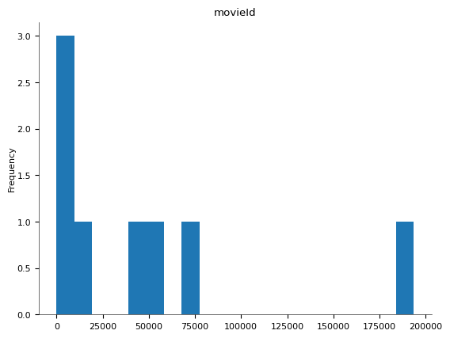

Values

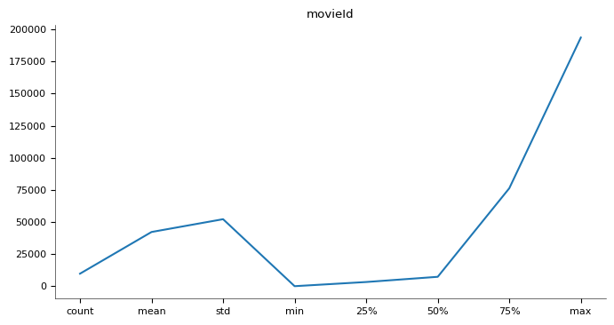

```python
# Descriptive Statistics for movies_df dataset
movies_df.describe()
```

|  | userId | movieId | timestamp |
| --- | --- | --- | --- |
| count | 3683.000000 | 3683.000000 | 3.683000e+03 |
| mean | 431.149335 | 27252.013576 | 1.320032e+09 |
| std | 158.472553 | 43490.558803 | 1.721025e+08 |
| min | 2.000000 | 1.000000 | 1.137179e+09 |
| 25% | 424.000000 | 1262.500000 | 1.137521e+09 |
| 50% | 474.000000 | 4454.000000 | 1.269833e+09 |
| 75% | 477.000000 | 39263.000000 | 1.498457e+09 |
| max | 610.000000 | 193565.000000 | 1.537099e+09 |

Distributions

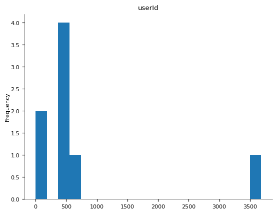

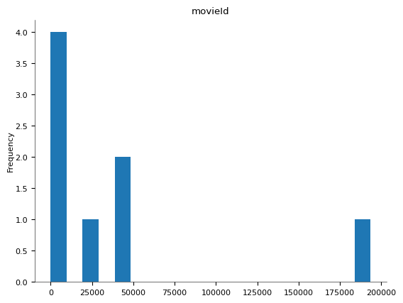

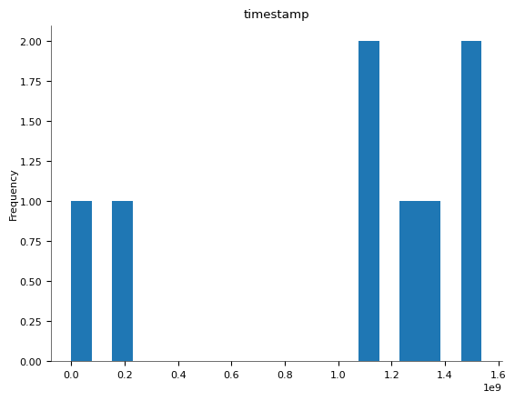

2-d distributions

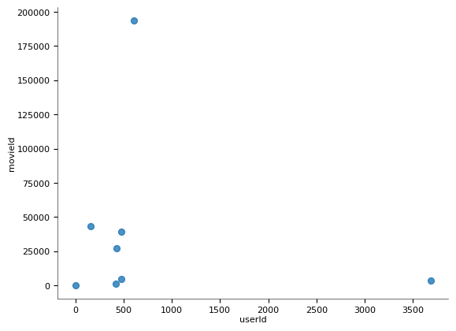

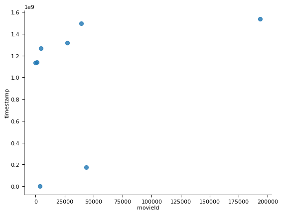

Time series

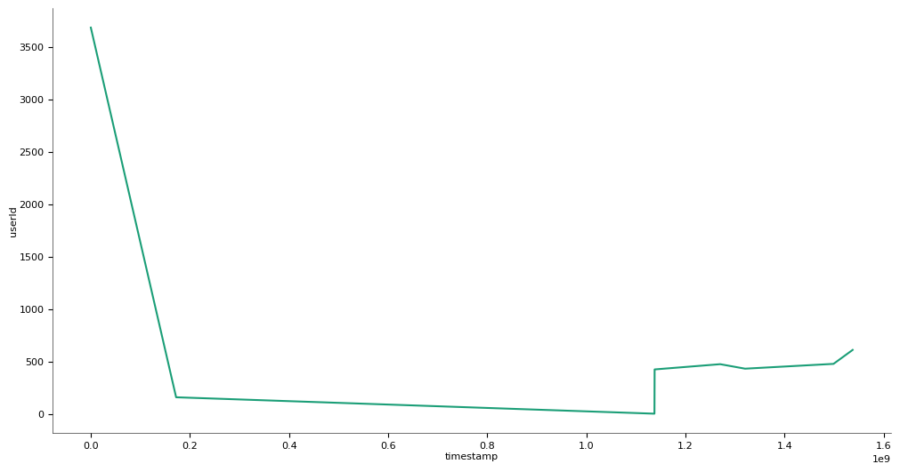

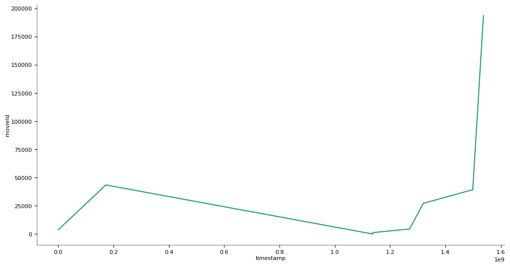

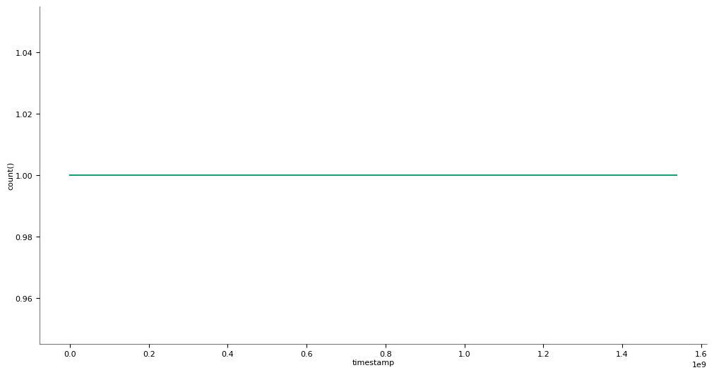

Values

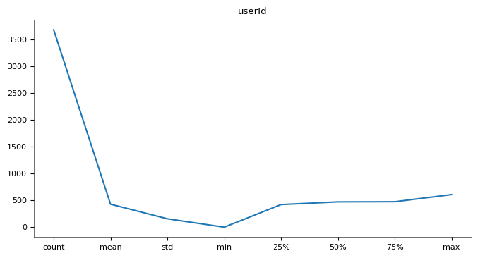

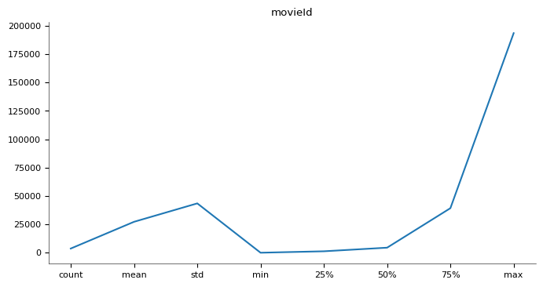

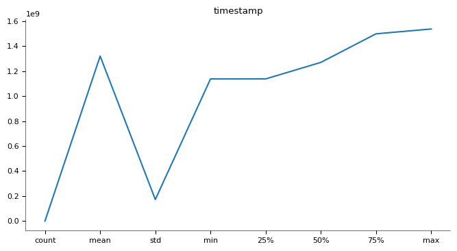

```python
# Descriptive Statistics for tags_df dataset
tags_df.describe()
```

|  | userId | movieId | rating | timestamp |
| --- | --- | --- | --- | --- |
| count | 100836.000000 | 100836.000000 | 100836.000000 | 1.008360e+05 |
| mean | 326.127564 | 19435.295718 | 3.501557 | 1.205946e+09 |
| std | 182.618491 | 35530.987199 | 1.042529 | 2.162610e+08 |
| min | 1.000000 | 1.000000 | 0.500000 | 8.281246e+08 |
| 25% | 177.000000 | 1199.000000 | 3.000000 | 1.019124e+09 |
| 50% | 325.000000 | 2991.000000 | 3.500000 | 1.186087e+09 |
| 75% | 477.000000 | 8122.000000 | 4.000000 | 1.435994e+09 |
| max | 610.000000 | 193609.000000 | 5.000000 | 1.537799e+09 |

Distributions

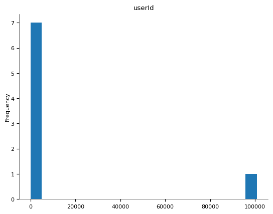

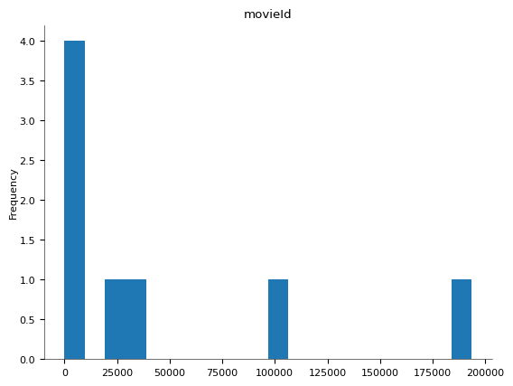

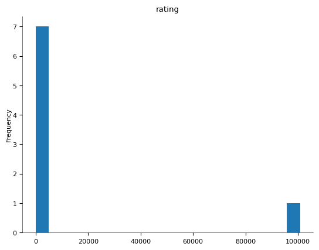

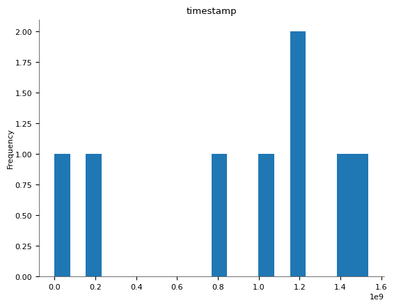

2-d distributions

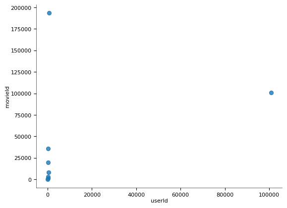

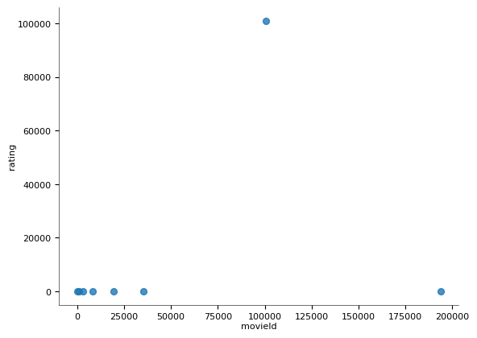

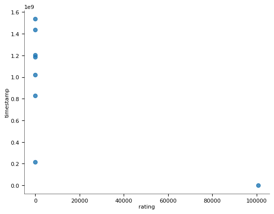

Time series

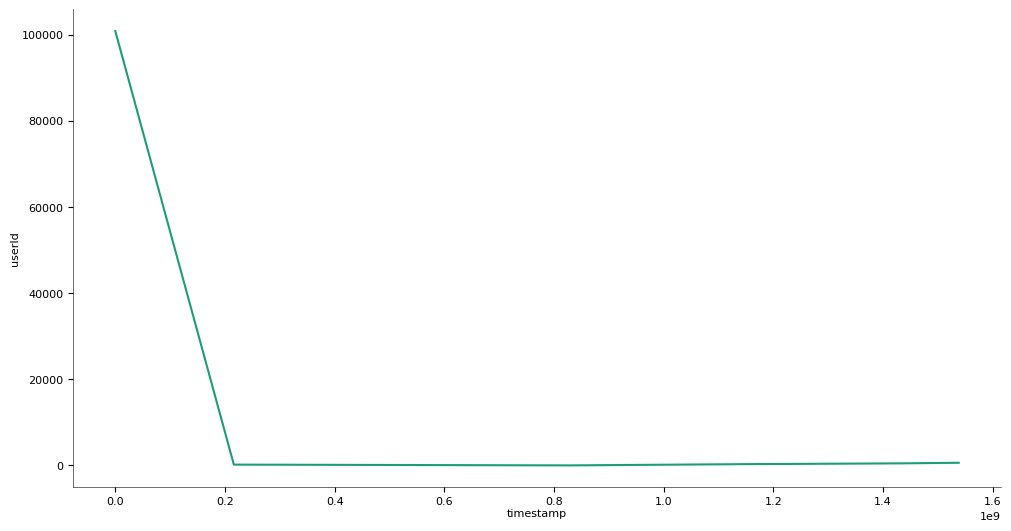

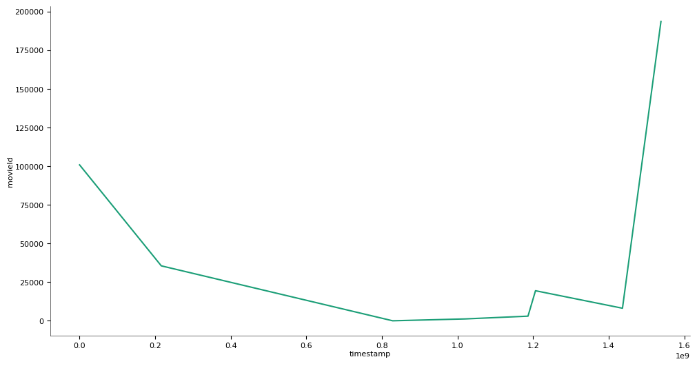

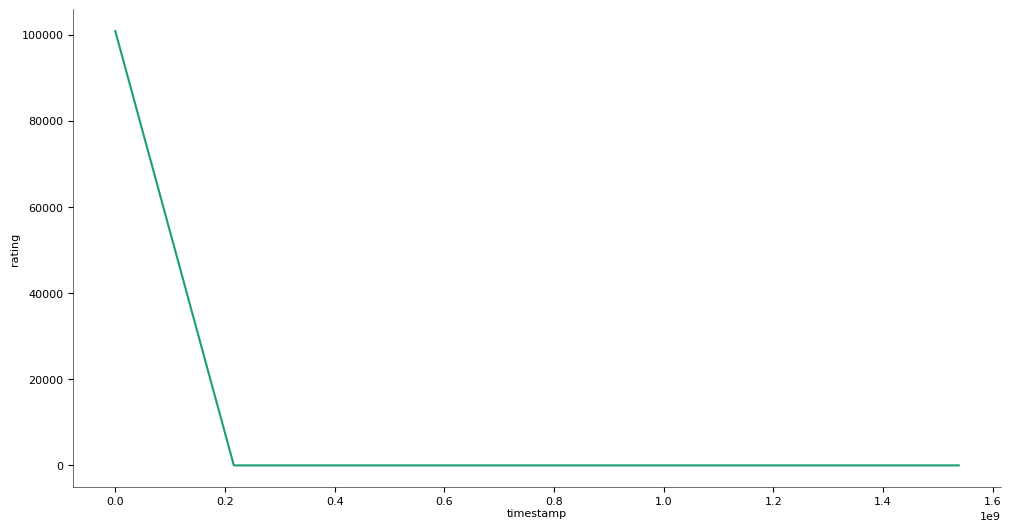

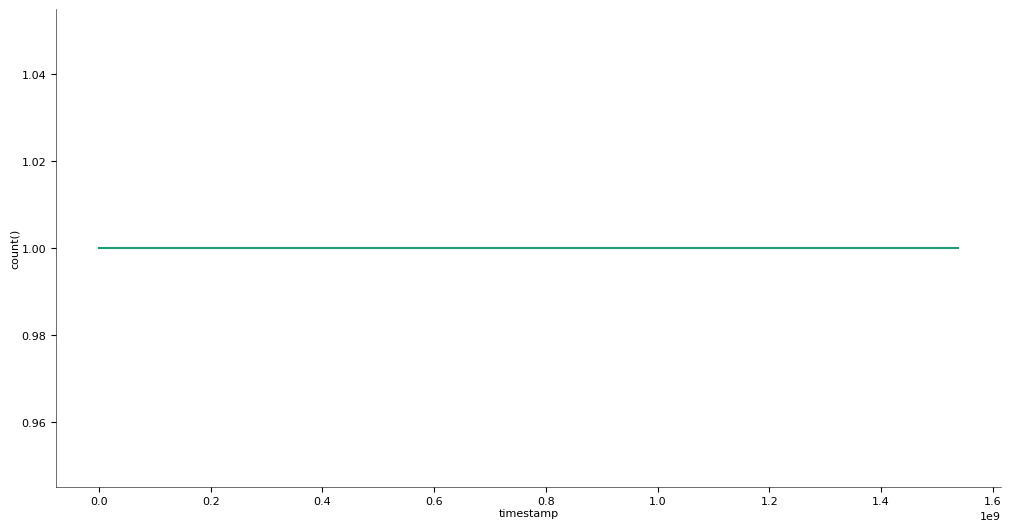

Values

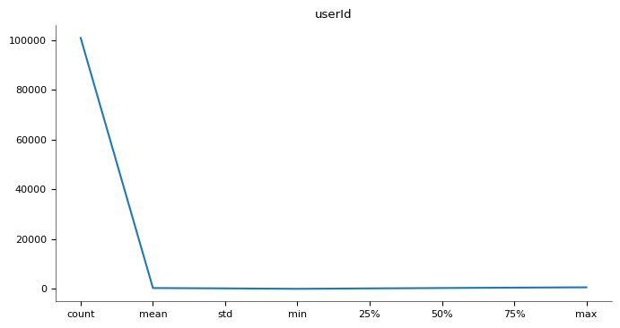

[3 more figures not shown]

```python
# Descriptive Statistics for ratings_df dataset
ratings_df.describe()
```